# Project Python Foundations: FoodHub Data Analysis

### Context

The number of restaurants in New York is increasing day by day. Lots of students and busy professionals rely on those restaurants due to their hectic lifestyles. Online food delivery service is a great option for them. It provides them with good food from their favorite restaurants. A food aggregator company FoodHub offers access to multiple restaurants through a single smartphone app.

The app allows the restaurants to receive a direct online order from a customer. The app assigns a delivery person from the company to pick up the order after it is confirmed by the restaurant. The delivery person then uses the map to reach the restaurant and waits for the food package. Once the food package is handed over to the delivery person, he/she confirms the pick-up in the app and travels to the customer's location to deliver the food. The delivery person confirms the drop-off in the app after delivering the food package to the customer. The customer can rate the order in the app. The food aggregator earns money by collecting a fixed margin of the delivery order from the restaurants.

### Objective

The food aggregator company has stored the data of the different orders made by the registered customers in their online portal. They want to analyze the data to get a fair idea about the demand of different restaurants which will help them in enhancing their customer experience. Suppose you are hired as a Data Scientist in this company and the Data Science team has shared some of the key questions that need to be answered. Perform the data analysis to find answers to these questions that will help the company to improve the business.

### Data Description

The data contains the different data related to a food order. The detailed data dictionary is given below.

### Data Dictionary

- order_id: Unique ID of the order
- customer_id: ID of the customer who ordered the food
- restaurant_name: Name of the restaurant
- cuisine_type: Cuisine ordered by the customer
- cost_of_the_order: Cost of the order
- day_of_the_week: Indicates whether the order is placed on a weekday or weekend (The weekday is from Monday to Friday and the weekend is Saturday and Sunday)
- rating: Rating given by the customer out of 5
- food_preparation_time: Time (in minutes) taken by the restaurant to prepare the food. This is calculated by taking the difference between the timestamps of the restaurant's order confirmation and the delivery person's pick-up confirmation.
- delivery_time: Time (in minutes) taken by the delivery person to deliver the food package. This is calculated by taking the difference between the timestamps of the delivery person's pick-up confirmation and drop-off information

### Let us start by importing the required libraries

```python
# Installing the libraries with the specified version.
!pip install numpy==1.25.2 pandas==1.5.3 matplotlib==3.7.1 seaborn==0.13.1 -q --user
```

**Note**: *After running the above cell, kindly restart the notebook kernel and run all cells sequentially from the start again.*

```python
# import libraries for data manipulation
import numpy as np
import pandas as pd

# import libraries for data visualization
import matplotlib.pyplot as plt
import seaborn as sns

#Customize ticks in the graphs
custom_params = {"axes.spines.right": False, "axes.spines.top": False}
sns.set_theme(style="ticks", rc=custom_params)

# Command to tell Python to actually display the graphs
%matplotlib inline
pd.set_option("display.float_format", lambda x: "%.2f" % x) #to display values upto 2 decimal places
```

### Understanding the structure of the data

```python
# uncomment and run the following lines for Google Colab
# from google.colab import drive
# drive.mount('/content/drive')
```

```python
# Use read_csv of the pandas library to read the data
df = pd.read_csv('/content/foodhub_order.csv')
```

```python
# Use head to display the first 5 rows
df.head()
```

|  | order_id | customer_id | restaurant_name | cuisine_type | cost_of_the_order | day_of_the_week | rating | food_preparation_time | delivery_time |
| --- | --- | --- | --- | --- | --- | --- | --- | --- | --- |
| 0 | 1477147 | 337525 | Hangawi | Korean | 30.75 | Weekend | Not given | 25 | 20 |
| 1 | 1477685 | 358141 | Blue Ribbon Sushi Izakaya | Japanese | 12.08 | Weekend | Not given | 25 | 23 |
| 2 | 1477070 | 66393 | Cafe Habana | Mexican | 12.23 | Weekday | 5 | 23 | 28 |
| 3 | 1477334 | 106968 | Blue Ribbon Fried Chicken | American | 29.20 | Weekend | 3 | 25 | 15 |
| 4 | 1478249 | 76942 | Dirty Bird to Go | American | 11.59 | Weekday | 4 | 25 | 24 |

### **Question 1:** How many rows and columns are present in the data? [0.5 mark]

```python
# Use shape to get the number of rows and columns
print(f'There are {df.shape[0]} rows and {df.shape[1]} columns in the dataset')
```

```
There are 1898 rows and 9 columns in the dataset
```

#### Observations: There are 1898 rows and 9 columns in the dataset

### **Question 2:** What are the datatypes of the different columns in the dataset? (The info() function can be used) [0.5 mark]

```python
# Use info() for the datatypes information
df.info()
```

```
<class 'pandas.core.frame.DataFrame'>
RangeIndex: 1898 entries, 0 to 1897
Data columns (total 9 columns):
 #   Column                 Non-Null Count  Dtype
---  ------                 --------------  -----
 0   order_id               1898 non-null   int64
 1   customer_id            1898 non-null   int64
 2   restaurant_name        1898 non-null   object
 3   cuisine_type           1898 non-null   object
 4   cost_of_the_order      1898 non-null   float64
 5   day_of_the_week        1898 non-null   object
 6   rating                 1898 non-null   object
 7   food_preparation_time  1898 non-null   int64
 8   delivery_time          1898 non-null   int64
dtypes: float64(1), int64(4), object(4)
memory usage: 133.6+ KB
```

#### Observations: There are 5 numeric variables(4 int and 1 float) and 4 object data types. The rating is an object but it is supposed to be an integer

```python
#Check the values for rating
df['rating'].unique()
```

```
array(['Not given', '5', '3', '4'], dtype=object)
```

```python
#We should not have 'Not given' but rather NaN for a not given
#Convert rating to integer giving NaN instead of Not given
df['rating'] = pd.to_numeric(df['rating'], errors='coerce')
```

```python
#Check the datatypes again
df.info()
```

```
<class 'pandas.core.frame.DataFrame'>
RangeIndex: 1898 entries, 0 to 1897
Data columns (total 9 columns):
 #   Column                 Non-Null Count  Dtype
---  ------                 --------------  -----
 0   order_id               1898 non-null   int64
 1   customer_id            1898 non-null   int64
 2   restaurant_name        1898 non-null   object
 3   cuisine_type           1898 non-null   object
 4   cost_of_the_order      1898 non-null   float64
 5   day_of_the_week        1898 non-null   object
 6   rating                 1162 non-null   float64
 7   food_preparation_time  1898 non-null   int64
 8   delivery_time          1898 non-null   int64
dtypes: float64(2), int64(4), object(3)
memory usage: 133.6+ KB
```

#### Observations: We now have 6 numeric variables(4 int and 2 float) and 3 object data types. The rating is now of float data type as it is supposed to be

### **Question 3:** Are there any missing values in the data? If yes, treat them using an appropriate method. [1 mark]

```python
# Use isnull() to find missing values
df.isnull().sum()
```

|  | 0 |
| --- | --- |
| order_id | 0 |
| customer_id | 0 |
| restaurant_name | 0 |
| cuisine_type | 0 |
| cost_of_the_order | 0 |
| day_of_the_week | 0 |
| rating | 736 |
| food_preparation_time | 0 |
| delivery_time | 0 |

**dtype:** int64

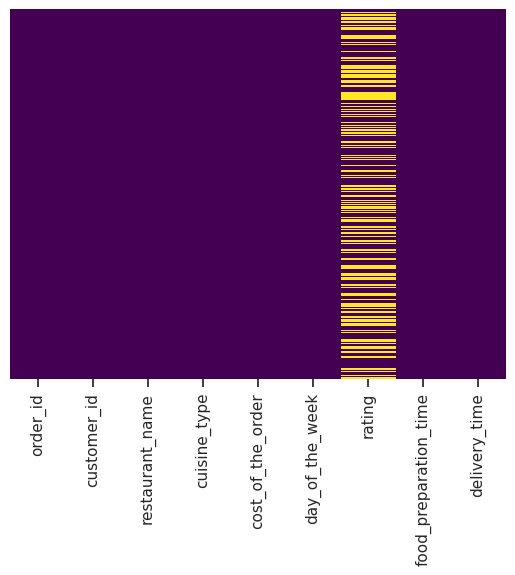

```python
#Checking for null values using a heatmap
sns.heatmap(df.isnull(),yticklabels=False,cbar=False,cmap='viridis');
```

#### Observations: There are no missing or null values in any of the features(columns) except for the rating where the ratings are not given. There is nothing that can be done about the not given ratings, we continue with them like that

### **Question 4:** Check the statistical summary of the data. What is the minimum, average, and maximum time it takes for food to be prepared once an order is placed? [2 marks]

```python
# Statistical summary for numeric data
df.describe().T
```

|  | count | mean | std | min | 25% | 50% | 75% | max |
| --- | --- | --- | --- | --- | --- | --- | --- | --- |
| order_id | 1898.00 | 1477495.50 | 548.05 | 1476547.00 | 1477021.25 | 1477495.50 | 1477969.75 | 1478444.00 |
| customer_id | 1898.00 | 171168.48 | 113698.14 | 1311.00 | 77787.75 | 128600.00 | 270525.00 | 405334.00 |
| cost_of_the_order | 1898.00 | 16.50 | 7.48 | 4.47 | 12.08 | 14.14 | 22.30 | 35.41 |
| rating | 1162.00 | 4.34 | 0.74 | 3.00 | 4.00 | 5.00 | 5.00 | 5.00 |
| food_preparation_time | 1898.00 | 27.37 | 4.63 | 20.00 | 23.00 | 27.00 | 31.00 | 35.00 |
| delivery_time | 1898.00 | 24.16 | 4.97 | 15.00 | 20.00 | 25.00 | 28.00 | 33.00 |

```python
# Statistical summary for object and categorical data
df.describe(include=[object, pd.Categorical]).T
```

|  | count | unique | top | freq |
| --- | --- | --- | --- | --- |
| restaurant_name | 1898 | 178 | Shake Shack | 219 |
| cuisine_type | 1898 | 14 | American | 584 |
| day_of_the_week | 1898 | 2 | Weekend | 1351 |

### **Question 5:** How many orders are not rated? [1 mark]

```python
#check the distinct values of the rating feature
df['rating'].unique()
```

```
array([nan,  5.,  3.,  4.])
```

```python
# Given that we have nan those are the unrated orders
df['rating'].isnull().sum()
```

```
736
```

#### Observations:

- 736 orders were not rated out of a possible total of 1898 orders in the dataset.

### Exploratory Data Analysis (EDA)

### **Question 6:** Explore all the variables and provide observations on their distributions. (Generally, histograms, boxplots, countplots, etc. are used for univariate exploration.) [9 marks]

#### **Observations on cost of the order**

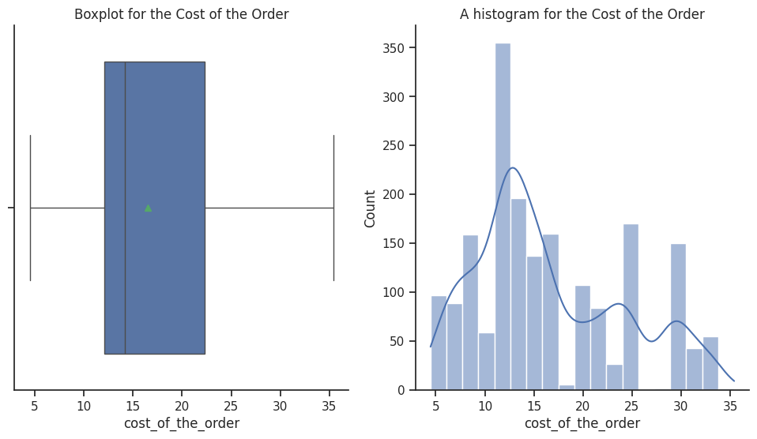

```python
# Set the figure size
plt.figure(figsize=(12, 6))

#Create two subplots for the variable
# Subplot 1 is the boxplot with a mean pointer
plt.subplot(1, 2, 1) # row 1, col 2 index 1
sns.boxplot(x='cost_of_the_order', data=df,showmeans=True)
plt.title("Boxplot for the Cost of the Order")

#subplot 2 is the histogram with a kde line
plt.subplot(1, 2, 2) # index 2
sns.histplot(x='cost_of_the_order', data=df, kde=True)
plt.title("A histogram for the Cost of the Order");
```

#### **Observations on delivery time**

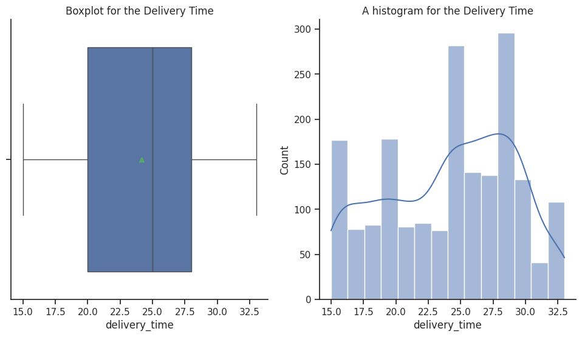

```python
# Set the figure size
plt.figure(figsize=(12, 6))

#Create two subplots for the variable
# Subplot 1 is the boxplot with a mean pointer
plt.subplot(1, 2, 1) # row 1, col 2 index 1
sns.boxplot(x='delivery_time', data=df, showmeans=True)
plt.title("Boxplot for the Delivery Time")

#subplot 2 is the histogram with a kde line
plt.subplot(1, 2, 2) # index 2
sns.histplot(x='delivery_time', data=df, kde=True)
plt.title("A histogram for the Delivery Time");
```

#### **Observations on Food preparation time**

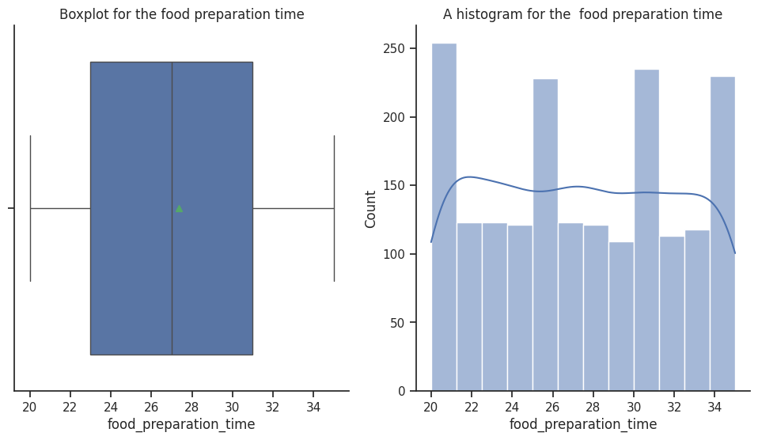

```python
# Set the figure size
plt.figure(figsize=(12, 6))

#Create two subplots for the variable
# Subplot 1 is the boxplot with a mean pointer
plt.subplot(1, 2, 1) # row 1, col 2 index 1
sns.boxplot(x='food_preparation_time', data=df,showmeans=True)
plt.title("Boxplot for the food preparation time")

#subplot 2 is the histogram with a kde line
plt.subplot(1, 2, 2) # index 2
sns.histplot(x='food_preparation_time', data=df, kde=True)
plt.title("A histogram for the  food preparation time");
```

#### Observations:

- The food preparation time seems to be symmetrical but after more consideration it shows that it is slightly right skewed because the mean is greater than the median, and the mode is smaller than the median, which means more of the values are on the right side of the median.

#### **Observations on day of the week**

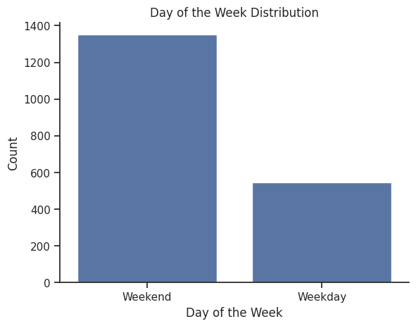

```python
#Use a countplot to view the distribution of the day of the week
sns.countplot(x='day_of_the_week', data=df)

#Add a title and labels to the axis
plt.xlabel('Day of the Week')
plt.ylabel('Count')
plt.title('Day of the Week Distribution');
```

#### Observations: More than half of the orders are placed on weekends compared to weekdays

#### **Observations on cuisine type**

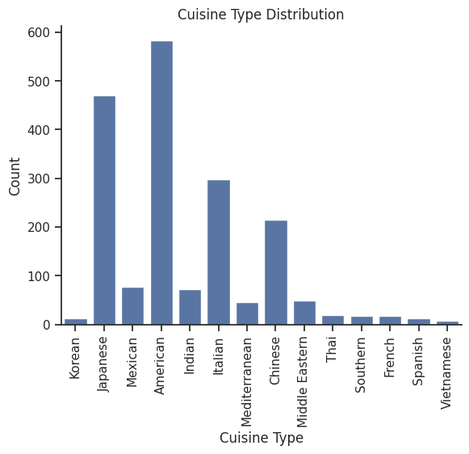

```python
#Create a countplot for the categorical variable  cuisine_type
sns.countplot(x='cuisine_type', data=df)
plt.tick_params(axis='x', rotation=90)

#Add a title and labels to the axis
plt.xlabel('Cuisine Type')
plt.ylabel('Count')
plt.title('Cuisine Type Distribution');
```

#### **Observations on customer ratings**

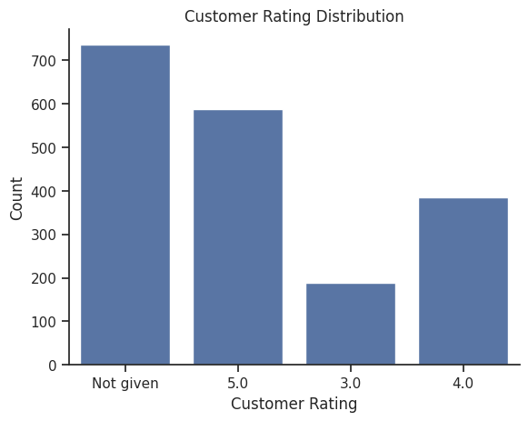

```python
#To include the nan values we use the following and represent it with 'Not given'
df['rating'] = df['rating'].fillna('Not given')
#Create a countplot for the categorical variable  customer_rating
sns.countplot(x='rating', data=df)

#Add a title and labels to the axis
plt.xlabel('Customer Rating')
plt.ylabel('Count')
plt.title('Customer Rating Distribution');
```

#### Observations: A lot of orders, more than 700 were not given a rating by customers. We do not have ratings 1 and 2, which means customers tend to rate when they are somewhat satisifed with the service/product

#### **Observations on order ID**

```python
#Find the total order IDs and those that are unique, to find repeating/duplicate orders
total_order_IDs = df['order_id'].value_counts().sum()

unique_order_IDs = df['order_id'].nunique()

print(f'There are {total_order_IDs} total orders in the dataset and only {unique_order_IDs} order of those are unique')
```

```
There are 1898 total orders in the dataset and only 1898 order of those are unique
```

#### Observations: The number of Order IDs in the dataset and the number of unique Order IDs is equal which means we do not have duplicates in our Order IDs (as expected)

#### **Observations on customer ID**

```python
#Find the total customer IDs and those that are unique, to find repeating/duplicate customers
total_cust_IDs = df['customer_id'].value_counts().sum()

unique_cust_IDs = df['customer_id'].nunique()

print(f'There are {total_cust_IDs} total customers in the dataset and only {unique_cust_IDs} customers of those are unique')
```

```
There are 1898 total customers in the dataset and only 1200 customers of those are unique
```

#### Observations: The unique customer IDs are less than the total number of customer IDs which means some of the customers are repeat customers. It is safe to assume that these are repeat customers because we only have unique orders in our dataset

#### **Observations on the restaurant name**

```python
#Find the total restaurant names and those that are unique, to find repeating/duplicate restaurants
total_rest_names = df['restaurant_name'].value_counts().sum()

unique_rest_names = df['restaurant_name'].nunique()

print(f'There are {total_rest_names} restaurants in the dataset and only {unique_rest_names} restaurants of those are unique')
```

```
There are 1898 restaurants in the dataset and only 178 restaurants of those are unique
```

#### Observations: Just like the customer IDs, the number of unique restaurant names is less than the total number of restaurants, which makes sense because one restaurant can have more than 1 orders placed on it at any given time. It is safe to say these are not duplicates because all the orders are unique

### **Question 7**: Which are the top 5 restaurants in terms of the number of orders received? [1 mark]

```python
# Take the value counts of each restaurant name (column) in the dataset
df['restaurant_name'].value_counts().head()
```

| restaurant_name | count |
| --- | --- |
| Shake Shack | 219 |
| The Meatball Shop | 132 |
| Blue Ribbon Sushi | 119 |
| Blue Ribbon Fried Chicken | 96 |
| Parm | 68 |

**dtype:** int64

#### Observations: Shake Shack is the top restaurant with 219 orders, followed by The Meatball Shop with 132 orders, Blue Ribbon Sushi with 119 orders, Blue Ribbon Freid Chicken with 96 orders and lastly Parm with 68 orders.

### **Question 8**: Which is the most popular cuisine on weekends? [1 mark]

```python
# Filter the data to get the weekend values only then take the value counts of each cuisine type
df[df['day_of_the_week'] == 'Weekend']['cuisine_type'].value_counts().head(1)
```

| cuisine_type | count |
| --- | --- |
| American | 415 |

**dtype:** int64

```python
#Use the group by to group the data by day of the week, then get value counts for each cuisine type
df.groupby(['day_of_the_week'])['cuisine_type'].value_counts().sort_values(ascending=False).head(1)
```

| day_of_the_week | cuisine_type | count |
| --- | --- | --- |
| Weekend | American | 415 |

**dtype:** int64

#### Observations: The American is the most ordered or most popular cuisine on weekends

### **Question 9**: What percentage of the orders cost more than 20 dollars? [2 marks]

```python
# Use shape on the filtered cost of the order to get the percentage
perc = round((df[df['cost_of_the_order'] > 20].shape[0]/df.shape[0]*100),2)
print(f'The percentage of orders which cost more than 20 dollars is {perc}%')
```

```
The percentage of orders which cost more than 20 dollars is 29.24%
```

#### Observations: 29.24% of the 1898 orders costs more than 20 dollars

### **Question 10**: What is the mean order delivery time? [1 mark]

```python
# Take the mean of the delivery time in the dataset
mean_order = round((df['delivery_time'].mean()),2)
print(f'The mean order delivery time is {mean_order} minutes')
```

```
The mean order delivery time is 24.16 minutes
```

#### Observations: The mean order delivery time is 24.16 minutes

### **Question 11:** The company has decided to give 20% discount vouchers to the top 3 most frequent customers. Find the IDs of these customers and the number of orders they placed. [1 mark]

```python
# Get the value counts of each of the customer IDs then take the top 3 using the head
df['customer_id'].value_counts().head(3)
```

| customer_id | count |
| --- | --- |
| 52832 | 13 |
| 47440 | 10 |
| 83287 | 9 |

**dtype:** int64

#### Observations: Customers 52832, 47440 and 83287 placed 13, 10 and 9 orders respectively. This makes them the most frequent customers who deserve a 20% discount

### **Question 12**: Perform a multivariate analysis to explore relationships between the important variables in the dataset. (It is a good idea to explore relations between numerical variables as well as relations between numerical and categorical variables) [10 marks]

#### **Cuisine type vs food preparation time**

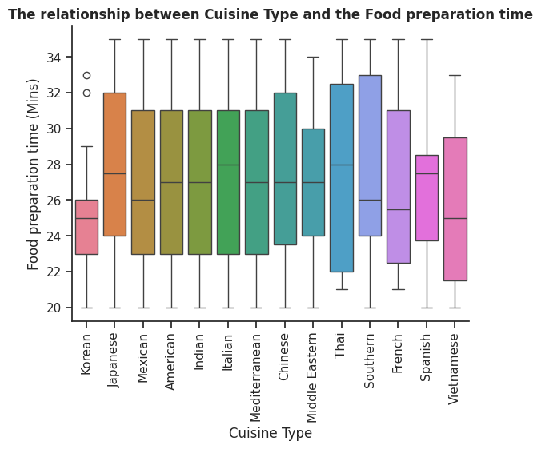

```python
#Use a boxplot to get the relationship between cuisine type and preparation time
sns.boxplot(x='cuisine_type',y ='food_preparation_time', hue='cuisine_type', data=df)
plt.tick_params(axis='x', rotation=90)

#Add a title and labels to the axis
plt.xlabel('Cuisine Type')
plt.ylabel('Food preparation time (Mins)')
plt.title('The relationship between Cuisine Type and the Food preparation time', fontsize=12, fontweight='bold');
```

#### Observations:

- The minimum time taken to prepare the different cuisines ranges from 20 to 21 minutes
- The maximum time taken to prepare the cuisines ranges from 33 to 35 minutes
- There are outliers in the preparation of Korean cuisines, which means some orders took longer to get prepared compared to the rest of the orders of the same cuisine.

### **Cuisine type vs Food delivery time**

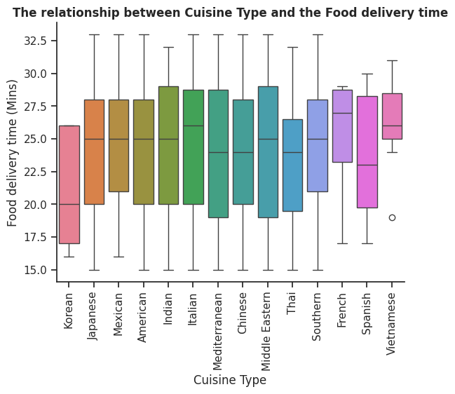

```python
#Use a boxplot to get the relationship between cuisine type and preparation time
sns.boxplot(x='cuisine_type',y ='delivery_time', hue='cuisine_type', data=df)
plt.tick_params(axis='x', rotation=90)

#Add a title and labels to the axis
plt.xlabel('Cuisine Type')
plt.ylabel('Food delivery time (Mins)')
plt.title('The relationship between Cuisine Type and the Food delivery time', fontsize=12, fontweight='bold');
```

#### **Cuisine type vs cost of the order**

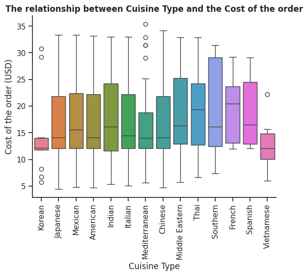

```python
#Use a boxplot for the relationship between the cuisine type and the cost of the order
sns.boxplot(x='cuisine_type',y='cost_of_the_order', hue='cuisine_type', data=df)
plt.tick_params(axis='x', rotation=90)

#Add a title and labels to the axis
plt.xlabel('Cuisine Type')
plt.ylabel('Cost of the order (USD)')
plt.title('The relationship between Cuisine Type and the Cost of the order', fontsize=12, fontweight='bold');
```

#### Observations:

- We see outliers in the cost of the order for several cuisines being Korean which has both lower and upper outliers, Mediterranean and Vietnamese which both has upper outliers only.
- Mediterranean has the maximum cost which is a little over 35 dollars and Japanaese seems to be having the minimum cost of the order with an amount less than 5 dollars.

#### **Day of the week vs delivery time**

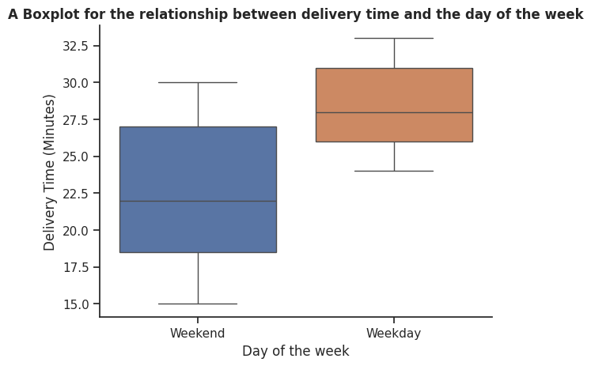

```python
#Use a boxplot to show the relationship between the day of the week and the delivery time
sns.boxplot(data=df, x='day_of_the_week', y='delivery_time', hue='day_of_the_week')

#Add a title and labels to the axis
plt.xlabel('Day of the week')
plt.ylabel('Delivery Time (Minutes)')
plt.title('A Boxplot for the relationship between delivery time and the day of the week', fontsize=12, fontweight='bold');
```

#### Observations:

- Delivery times are consistent with no outliers
- The median delivery time on weekends is lower, indicating faster deliveries compared to weekdays.

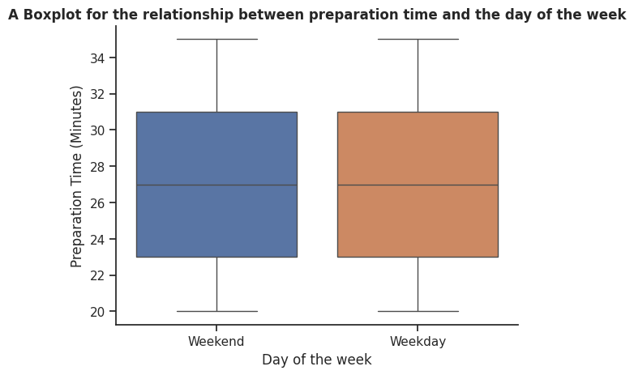

```python
#Use a boxplot to show the relationship between the day of the week and the delivery time
sns.boxplot(data=df, x='day_of_the_week', y='food_preparation_time', hue='day_of_the_week')

#Add a title and labels to the axis
plt.xlabel('Day of the week')
plt.ylabel('Preparation Time (Minutes)')
plt.title('A Boxplot for the relationship between preparation time and the day of the week', fontsize=12, fontweight='bold');
```

#### Observations:

- Preparation times are the same for weekends and weekdays

#### **Rating vs delivery time**

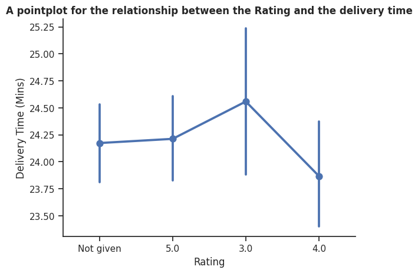

```python
#A pointplot showing the relationship between ratings and delivery time
sns.pointplot(data=df, x='rating', y='delivery_time')

#Add a title and labels to the axis
plt.xlabel('Rating')
plt.ylabel('Delivery Time (Mins)')
plt.title('A pointplot for the relationship between the Rating and the delivery time', fontsize=12, fontweight='bold');
```

#### Observations:

- The plot does not show a clear trend or correlation between the rating categories and delivery times, as the error bars overlap and the delivery times vary across different ratings

#### **Rating vs Cost of the order**

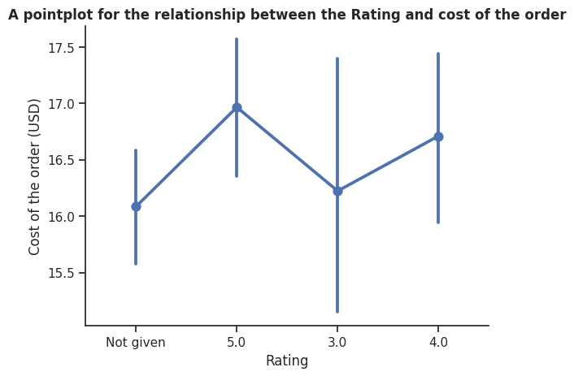

```python
#A pointplot showing the relationship between ratings and the cost of the order
sns.pointplot(data=df, x='rating', y='cost_of_the_order')

#Add a title and labels to the axis
plt.xlabel('Rating')
plt.ylabel('Cost of the order (USD)')
plt.title('A pointplot for the relationship between the Rating and cost of the order', fontsize=12, fontweight='bold');
```

#### Observations:

- There is no clear correlation or relationship between the rating and the cost of the order, this is due to the highly ogverlapping error bars on all the data data points. The rating 3 has more uncertainty due to longer error bars.

#### **Rating vs Food preparation time**

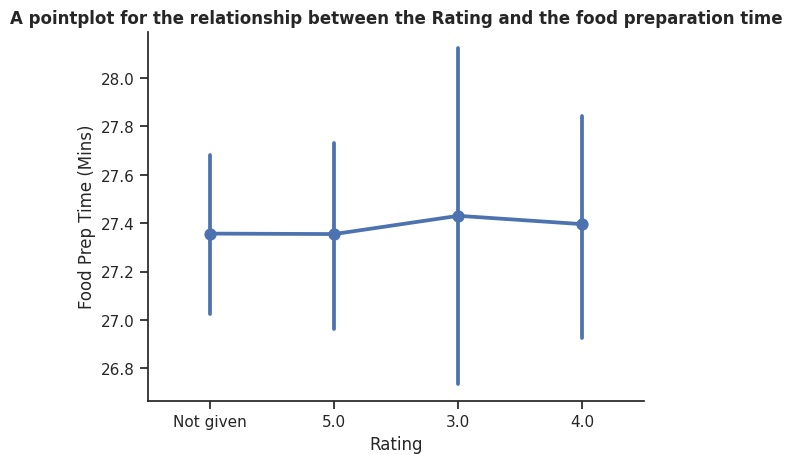

```python
#A pointplot showing the relationship between ratings and the food preparation time
sns.pointplot(data=df, x='rating', y='food_preparation_time')

#Add a title and labels to the axis
plt.xlabel('Rating')
plt.ylabel('Food Prep Time (Mins)')
plt.title('A pointplot for the relationship between the Rating and the food preparation time', fontsize=12, fontweight='bold');
```

#### Observations:There in no clear correlation but we can tell that the rating 3 has more uncertainty due to longer error bars. There is more spreadout ratings over various food preparation times.

#### **Rating vs Cuisine type**

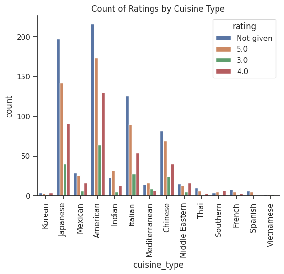

```python
#Use a boxplot for the relationship between the cuisine type and the cost of the order
sns.countplot(x='cuisine_type', hue='rating', data=df)
plt.title('Count of Ratings by Cuisine Type')
plt.tick_params(axis='x', rotation=90)
plt.show()
```

#### Observations: The countplot shows that for most cuisine types, a significant number of ratings are not given. However, among the given ratings, higher ratings (4 and 5) are more common across various cuisines. This suggests that customers tend to rate their experiences positively when they do provide ratings. This is also shown by the lack of ratings 1 and 2

#### **Correlation among numeric values**

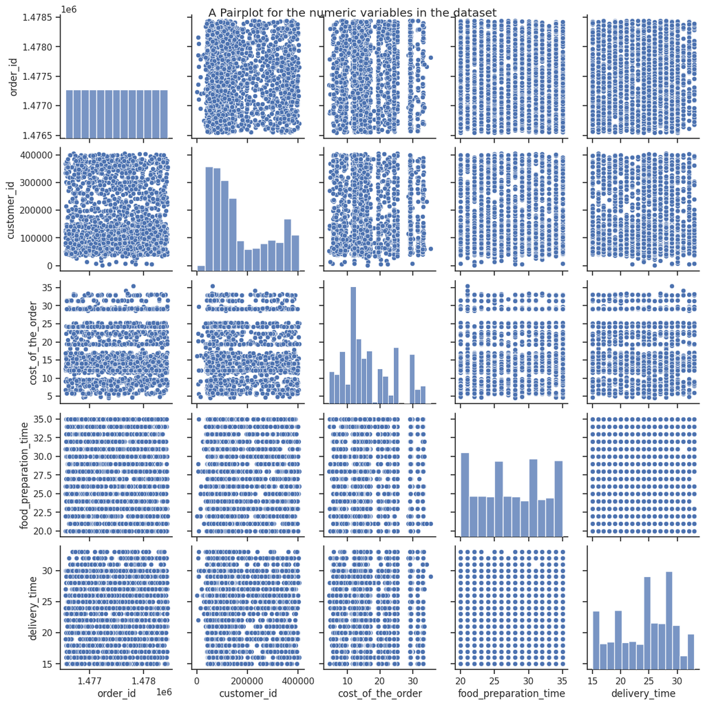

```python
#Correlation using the pairplot of all the numeric variables in the df dataset
pplot = sns.pairplot(df)
pplot.fig.suptitle("A Pairplot for the numeric variables in the dataset")

plt.show()
```

#### Observations: There seems to be no significant correlation between all the numeric variables in the dataset.

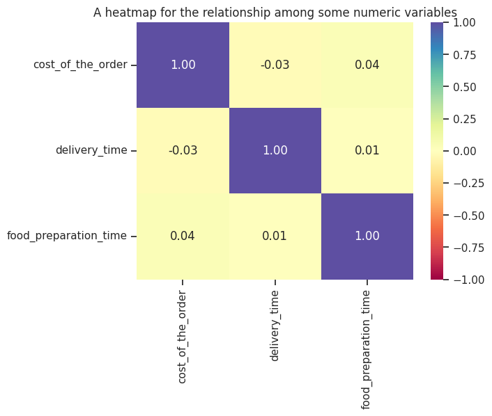

```python
#list all numeric values in a list
numeric_vals = ['cost_of_the_order', 'delivery_time', 'food_preparation_time']

ax = plt.axes()

#Create a heatmap to sure correlation among the above numeric values
pplot2 =sns.heatmap(df[numeric_vals].corr(), annot=True, vmin=-1, vmax=1, fmt=".2f", cmap="Spectral")

ax.set_title('A heatmap for the relationship among some numeric variables')
plt.show()
```

#### Observations: There seems to be none to insignificant correlation among the listed important variables in the dataset being the cost of the order, delivery time and food preparation time variables.

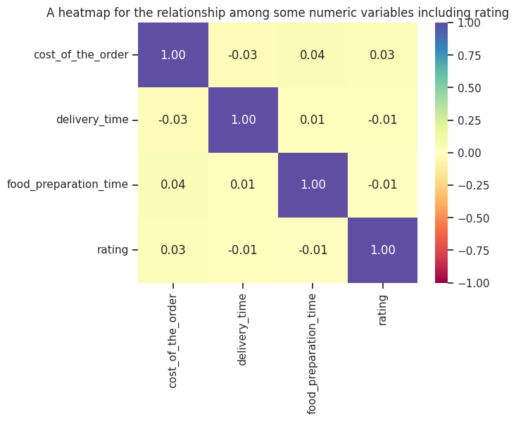

```python
#Here we will add rating to the mix but we will have to make it numeric first, by converting the 'Not given' to Nan
df['rating'] = pd.to_numeric(df['rating'], errors='coerce')

#list all numeric values in a list including rating
numeric_vals = ['cost_of_the_order', 'delivery_time', 'food_preparation_time', 'rating']

ax = plt.axes()

#Create a heatmap to sure correlation among the above numeric values
sns.heatmap(df[numeric_vals].corr(), annot=True, vmin=-1, vmax=1, fmt=".2f", cmap="Spectral")

ax.set_title('A heatmap for the relationship among some numeric variables including rating')
plt.show()
```

#### Observations: All the numeric variables in the dataset including the rating have no noted correlation.

### **Question 13:** The company wants to provide a promotional offer in the advertisement of the restaurants. The condition to get the offer is that the restaurants must have a rating count of more than 50 and the average rating should be greater than 4. Find the restaurants fulfilling the criteria to get the promotional offer. [3 marks]

```python
#Use groupby to find the aggregates(count, mean ) of the ratings for each restautant in the dataset and sort them by count
df.groupby('restaurant_name')['rating'].agg(['count', 'mean', 'median']).sort_values(by='count', ascending=False).head()
```

| restaurant_name | count | mean | median |
| --- | --- | --- | --- |
| Shake Shack | 133 | 4.28 | 4.00 |
| The Meatball Shop | 84 | 4.51 | 5.00 |
| Blue Ribbon Sushi | 73 | 4.22 | 4.00 |
| Blue Ribbon Fried Chicken | 64 | 4.33 | 4.50 |
| RedFarm Broadway | 41 | 4.24 | 4.00 |

#### Observations: The restaurants that qualify are Shake Shack, The Meatball Shop, Blue Ribbon Sushi and Blue Ribbon Fried Chicken which satisfies the greater than 50 count and the mean of 4. RedFarm Broadway does not qualify due to the less than 50 count of the rating

### **Question 14:** The company charges the restaurant 25% on the orders having cost greater than 20 dollars and 15% on the orders having cost greater than 5 dollars. Find the net revenue generated by the company across all orders. [3 marks]

```python
#Calculating the total revenue using a function that is then applied to the cost of the order
def revenue(x):
  if x > 20:
    return x*0.25
  elif x > 5:
    return x*0.15
  else:
    return 0

df['revenue'] = df['cost_of_the_order'].apply(revenue)
print(f"The company has generated a total revenue of US$ {round(df['revenue'].sum(),2)}")
```

```
The company has generated a total revenue of US$ 6166.3
```

```python
#DOING IT THE MANUAL WAY
#find revenue made from orders costing greater than 20 dollars
revenue_25 = df[df['cost_of_the_order'] > 20]['cost_of_the_order'].sum()*0.25

#find revenue made from orders greater than 5 dollars
revenue_15 = df[(df['cost_of_the_order'] > 5) & (df['cost_of_the_order'] < 20)]['cost_of_the_order'].sum()*0.15

#find total revenue
total_revenue = round(revenue_25 + revenue_15,2)
print(f'The company has generated a total revenue of US$ {total_revenue}')
```

```
The company has generated a total revenue of US$ 6166.3
```

#### Observations:The total revenue generated is USD 6166.30

### **Question 15:** The company wants to analyze the total time required to deliver the food. What percentage of orders take more than 60 minutes to get delivered from the time the order is placed? (The food has to be prepared and then delivered.) [2 marks]

```python
#Add a new column to the dataset which holds a calculated value of the
df['total_time'] = df['food_preparation_time'] + df['delivery_time']

#Calculate the precentage of orders which has a total time of more than 60 minutes
percentage = round((df[df['total_time'] > 60].shape[0]/df.shape[0]*100), 2)
print(f'The percentage of orders which take more than 60 minutes to get delivered is {percentage}%')
```

```
The percentage of orders which take more than 60 minutes to get delivered is 10.54%
```

#### Observations: Only 10.54% of the orders in the dataset took more than 60 minutes to get delivered from the time the order was placed.

### **Question 16:** The company wants to analyze the delivery time of the orders on weekdays and weekends. How does the mean delivery time vary during weekdays and weekends? [2 marks]

```python
# Use group by to find the mean of delivery time for each day of the week
df.groupby('day_of_the_week')['delivery_time'].mean()
```

| day_of_the_week | delivery_time |
| --- | --- |
| Weekday | 28.34 |
| Weekend | 22.47 |

**dtype:** float64

#### Observations: On average orders are delivered 6 minutes faster on weekends than on weekdays. This could be caused by traffic during weekday more especially when people make orders during lunch time.

### Conclusion and Recommendations

### **Question 17:** What are your conclusions from the analysis? What recommendations would you like to share to help improve the business? (You can use cuisine type and feedback ratings to drive your business recommendations.) [6 marks]

### Conclusions:

- Most orders are done on weekends
- A lot of orders were not rated and this might be a problem, because it might be difficult to find areas of improvement
- American is the most prevalent cuisine on both weekends and weekdays
- Preparation time is the same on weekends and weekdays but the delivery time varies, deliveries are faster on weekends than on weekdays

### Recommendations:

- The company should find means of encouraging the customers to rate the order so as to identify areas for improvement, this can be done by offering discounts or rewards for customers who provide ratings.
- The company can make it easy and mandatory for customers to leave ratings by integrating a simple rating system in their app or website.
- All restaurants should be encouraged to include a variety of cuisines more especially the top 5 most ordered cuisines, in addition to those that are specific to their area
- The company should consider using motorbikes on weekdays at the times when there is traffic to improve weekday delivery times